# Citations in the Volcker Rule

Steven Rashin

September 24, 2020

## Purpose

This project analyzes who the Federal Reserve is citing in the Volcker Rule.

## Data

This data is from https://www.federalregister.gov/documents/full_text/xml/2014/01/31/2013-31511.xml

```r
fr <- "https://www.federalregister.gov/documents/full_text/xml/2014/01/31/2013-31511.xml"

# Extract footnotes
all_footnotes <- xml_text( xml_find_all( fr %>% read_xml(), "//FTNT" ) )

# Show examples of footnotes
footnotes_in_data_frame <- all_footnotes %>%
  str_squish() %>%
  tibble::enframe(value = "text",  name = "id")
```

The footnotes are stored in the XML on the Federal Register API.[^1] There are several types of footnotes:[^2]

1. 100 See ABA (Keating); Credit Suisse (Seidel).
- This text of the footnote refers to the following text in the body of the rule: “Commenters argued, for example, that an overly broad definition of trading account may cause traditional bank activities important to safety and soundness of a banking entity to fall within the prohibition on proprietary trading to the detriment of banking organizations, customers, and financial markets.”
2. 549 See, e.g., AllianceBernstein; Chamber (Dec. 2011); Members of Congress (Dec. 2011); Wellington; Sen. Hagan; Prof. Duffie; IR&M; MetLife; Lord Abbett; Liberty Global; NYSE Euronext; SIFMA et al. (Prop. Trading) (Feb. 2012); NCSHA; ASF (Feb. 2012) (stating that “[f]ailure to permit the activities necessary for banking entities to act in [a] market-making capacity [in asset-backed securities] would have a dramatic adverse effect on the ability of securitizers to access the asset-backed securities markets and thus to obtain the debt financing necessary to ensure a vibrant U.S. economy”); Credit Suisse (Seidel); JPMC; Morgan Stanley; Barclays; Goldman (Prop. Trading); BoA; Citigroup (Feb. 2012); STANY; BlackRock; Chamber (Feb. 2012); IHS; BDA (Feb. 2012); Fixed Income Forum/Credit Roundtable; ACLI (Feb. 2012); Wells Fargo (Prop. Trading); Abbott Labs et al. (Feb. 14, 2012); Abbott Labs et al. (Feb. 21, 2012); T. Rowe Price; FEI; AFMA; SSgA (Feb. 2012); PNC et al.; ICI (Feb. 2012); British Bankers’ Ass’n.; Oliver Wyman (Dec. 2011); Oliver Wyman (Feb. 2012); GE (Feb. 2012); Thakor Study (stating that when a firm’s cost of capital goes up, it invests less—resulting in lower economic growth and lower employment—and citing supporting data indicating that a 1 percent increase in the cost of capital would lead to a $55 to $82.5 billion decline in aggregate annual capital spending by U.S. nonfarm firms and job losses between 550,000 and 1.1 million per year in the nonfarm sector). One commenter further noted that a higher cost of capital can lead a firm to make riskier, short-term investments. See Thakor Study.
- “As discussed above, several commenters stated that the proposed rule would impact a banking entity’s ability to engage in market making-related activity. Many of these commenters represented that, as a result, the proposed exemption would likely result in reduced liquidity … reduced price discovery or price transparency,”
3. 501 12 U.S.C. 1851(d)(1)(B).
- “The statute specifically permits banking entities to continue to provide these beneficial services to their clients, customers, and counterparties.”

Note, however, that since the XML does not separate commenters consistently, there are a number of text blocks with one citation that should not be on this list because they are not citations but are blocks of text with the same formatting as citations (see the section on limits for a more detailed explanation). Expanding this approach to use on other joint SEC/Federal Reserve rules would require the help of research assistants as, unlike most SEC rules, there is no dictionary that maps abbreviations to commenters. See, for example the following citation from the SEC’s Conflict Minerals rule which regulates the use of minerals from the Democratic Republic of Congo, among other places:

> 40 Among the foreign officials to provide comment letters was the DRC’s Minister of Mines. See letters from Martin Kabwelulu, Minister of Mines, Democratic Republic of the Congo (July 15, 2011) (“DRC Ministry of Mines I”); Martin Kabwelulu, Minister of Mines, Democratic Republic of the Congo (Oct. 15, 2011) (“DRC Ministry of Mines II”); and Martin Kabwelulu, Minister of Mines, Democratic Republic of the Congo (Nov. 8, 2011) (“DRC Ministry of Mines III”).

In the Volcker Rule, by contrast, readers are left to assume “BoA” is the Bank of America rather than the Bank of Austria or Azerbaijan.

```r
# Pattern in this rule is that commenters are in comments that begin with "see"
only_cited_commenters <- footnotes_in_data_frame[grepl(pattern = "see", x = footnotes_in_data_frame$text, ignore.case = T),]

# Separate into 64 columns, the 64 is because splitting into n columns proved not doable
# Clear out see and see e.g, to better get at the first organization and get rid of periods so Goldman. and Goldman are the same

# get maximum number of semi colons in a line
max_cols <- 1 + max(str_count(string = only_cited_commenters$text, pattern = ";"))

only_cited_commenters$text <- gsub(x = only_cited_commenters$text,
     pattern = "See|See, e\\.g\\.|^\\d{1,}|, e\\.g\\., |See also|See also,|\\.|,\\s{1}",
     replacement = "", ignore.case = T)

separate_orgs <- only_cited_commenters %>%
  separate(text, ";",into = paste("Org", 1:max_cols, sep = "_"), fill = "right")

#get rid of whitespace that's either leading, trailing, or double spaced inside
separate_orgs[] <- lapply(separate_orgs, str_squish)

# now get count.  first apply table function to all columns
count_by_column <- separate_orgs %>% map(table)

# now unlist all columns
count_by_column_together <- unlist(count_by_column, use.names = T)

# The formatting is messed up - only the integers are columns, the actual names are a "name" function
# AND have column prefixes that we want to 86
ids_and_freqs_by_col <- data.frame(names(count_by_column_together), count_by_column_together, stringsAsFactors = F)
row.names(ids_and_freqs_by_col) <- NULL
names(ids_and_freqs_by_col) <- c("Org", "Freq")

#Get rid of unneccary ids like id.1356
ids_and_freqs_by_col <- ids_and_freqs_by_col[!grepl(pattern = "^id\\.\\d{1,}$", x = ids_and_freqs_by_col$Org, ignore.case = F),]

# See if we can separate (Feb 2014) from (LOTS OF TEXT...).  If there are more than 20 characters
# after the first parenthesis, the get rid of the parenthesis

# Now make Org_1BoA and Org_2BoA same thing
ids_and_freqs_by_col$Org <- gsub(x = ids_and_freqs_by_col$Org,
     pattern = "^Org_\\d{1,}\\.",
     replacement = "", ignore.case = T)

# Now sum by group so BoA 45 and BoA 30 become BoA 75
ids_and_freqs_by_col <- ids_and_freqs_by_col %>%
  mutate(
        #Get rid of everything after the last parenthesis
        Org = gsub("(\\)).*","\\1",Org),
        Org = str_squish(Org)) %>%
  group_by(Org) %>%
  dplyr::summarise(Frequency = sum(Freq))


# separete out SIFMA (Feb 2017) from "Alfred Brock (stating there is no such thing as a “sophisticated party”)"
ids_and_freqs_by_col <- ids_and_freqs_by_col %>%
  mutate(first_paren = unlist(lapply(X = gregexpr(pattern = "\\(", text = Org), FUN = min)),
         # if no parenthesis (gregexpr value =1, make sure string is at max length of the string)\
         org_len = nchar(Org),
         first_paren = ifelse(first_paren == -1, org_len, first_paren),
         total_length_string_after_first_paren = nchar(substr(x = Org, start = first_paren, stop = org_len)),
         comments_on_comments = ifelse(total_length_string_after_first_paren > 30, 1, 0),
         comments_on_comments_big = ifelse(total_length_string_after_first_paren > 200, 1, 0),
         # if more than 10 words before a parenthesis, don't count this as a detailed comment
         # Keep this rule out for now, found examples where this isn't true See
         # To the extent that an AP for an ETF is able to meet the terms of the underwriting exemption for its activityit may be able to retain ETF shares that it created if it had a reasonable expectation of buying interest in the ETF shares and engages in reasonable efforts to sell the ETF shares SIFMA et al (Prop Trading)
         # comments_on_comments = ifelse(qdap::word_count(substr(x = Org,start = 1, stop = first_paren-1))> 20, 0, comments_on_comments),
         Org = ifelse(total_length_string_after_first_paren > 20, str_squish(substr(Org, start = 1, stop = first_paren-1)), str_squish(Org)),
         Org = ifelse(nchar(Org)==0, "No Org", Org)
      ) %>%
  group_by(Org) %>%
  dplyr::summarise(Frequency = sum(Frequency),
            Detailed_Mentions = sum(comments_on_comments),
            Long_Detailed_Mentions = sum(comments_on_comments_big))
```

## Who Is Cited Most Frequently?

The most frequently cited commenters are, predominantly financial firms such as Bank of America, Goldman Sachs, and JP Morgan Chase. Note that these firms are represented more than once, through multiple letters and throught trade associations such as SIFMA, ICI, and the Chamber of Commerce.

```r
# Show top 100 commenters
knitr::kable(ids_and_freqs_by_col %>%
               dplyr::select(Org, Frequency) %>%
               arrange(desc(Frequency)) %>% top_n(100),
             col.names = c("Organization","Total Cites")) %>%
  kable_styling(bootstrap_options = c("striped", "hover")) %>%
  scroll_box(width = "100%", height = "400px")
```

Organization

Total Cites

Goldman (Prop Trading)

276

SIFMA et al (Prop Trading)

270

Occupy

241

BoA

210

JPMC

175

AFR et al (Feb 2012)

148

Credit Suisse (Williams)

139

RBC

138

Barclays

133

Sens Merkley & Levin (Feb 2012)

130

Public Citizen

120

Morgan Stanley

119

ABA (Keating)

116

ICI (Feb 2012)

115

SIFMA et al (Covered Funds)

107

Credit Suisse (Seidel)

101

IIB/EBF

88

Allen & Overy

85

Japanese Bankers Ass’n

83

Chamber (Feb 2012)

82

Wells Fargo (Prop Trading)

74

ASF (Feb 2012)

73

ISDA (Feb 2012)

66

SSgA (Feb 2012)

58

UBS

52

SIFMA (Securitization)

51

Better Markets (Feb 2012)

50

Citigroup (Feb 2012)

47

Alfred Brock

46

State Street (Feb 2012)

46

Wellington

44

SIFMA (Asset Mgmt)

43

Comm on Capital Markets Regulation

41

Goldman (Covered Funds)

40

PNC et al

40

SIFMA et al (PropTrading)

39

Arnold & Porter

38

PNC

38

AFME et al

37

GE (Feb 2012)

37

NYSE Euronext

37

Prof Duffie

37

Capital Group

36

T Rowe Price

36

ACLI (Feb 2012)

35

MetLife

35

CIEBA

34

Fidelity

34

final rule § __4(b)

34

Oliver Wyman (Feb 2012)

34

12 USC 1851(d)

33

ICI Global

33

BlackRock

32

Cadwalader

32

EFAMA

31

Johnson & Prof Stiglitz

31

final rule § __10(c)

30

Union Asset

30

Ass’n of Institutional Investors (Feb 2012)

28

FTN

28

Banco de México

27

SVB

27

Australian Bankers Ass’n (Feb 2012)

26

HSBC

25

TCW

25

Invesco

24

STANY

24

Vanguard

24

BNY Mellon et al

23

Fixed Income Forum/Credit Roundtable

23

ISDA (Apr 2012)

23

John Reed

23

Katten

23

BDA (Feb 2012)

22

PUC Texas

21

RMA

21

Ashurst

20

Ass’n of German Banks

20

EBF

20

19

Citigroup (Jan 2012)

19

Fin Services Roundtable (Feb 32012)

19

Sutherland

19

AllianceBernstein

18

Am Express

18

CalPERS

18

Cleary Gottlieb

18

ICFR

18

Investure

18

LSTA (Feb 2012)

18

NAMIC

18

final rule § __4(a)

17

IAA

17

IIF

17

Eaton Vance

16

NAIB et al

16

Oliver Wyman (Dec 2011)

16

Société Générale

16

Stephen Roach

16

Allen & Overy (Clearing)

15

Paul Volcker

15

SIFMA

15

Wells Fargo (Covered Funds)

15

```r
# Show top 100 commenters with detailed mentions
knitr::kable(ids_and_freqs_by_col %>%
               dplyr::select(Org, Detailed_Mentions) %>%
               arrange(desc(Detailed_Mentions)) %>% top_n(100),
             col.names = c("Organization","Detailed Cites"),
             table.attr = "style='width:30%;'") %>%
  kable_styling(bootstrap_options = c("striped", "hover"),full_width = F) %>%
  scroll_box(width = "100%", height = "400px")
```

| Organization | Detailed Cites |
| --- | --- |
| Occupy | 13 |
| BoA | 9 |
| RBC | 9 |
| JPMC | 7 |
| Morgan Stanley | 7 |
| Barclays | 6 |
| CIEBA | 6 |
| Fidelity | 4 |
| Johnson & Prof Stiglitz | 4 |
| NYSE Euronext | 4 |
| BNY Mellon et al | 3 |
| Capital Group | 3 |
| Japanese Bankers Ass’n | 3 |
| PNC | 3 |
| Public Citizen | 3 |
| Thakor Study | 3 |
| 17 CFR 242204 | 2 |
| Allen & Overy | 2 |
| Banco de México | 2 |
| CFA Inst | 2 |
| Cleary Gottlieb | 2 |
| FSOC study | 2 |
| id | 2 |
| IIB/EBF | 2 |
| infra Part IVC3 | 2 |
| Nationwide | 2 |
| Prof Duffie | 2 |
| Société Générale | 2 |
| TCW | 2 |
| Vanguard | 2 |

[output cut: 115 more lines]

```r
# Show top 100 commenters with longer detailed mentions
knitr::kable(ids_and_freqs_by_col %>%
               dplyr::select(Org, Long_Detailed_Mentions) %>%
               arrange(desc(Long_Detailed_Mentions)) %>% top_n(10),
             col.names = c("Organization","Long Cites"),
             table.attr = "style='width:30%;'") %>%
  kable_styling(bootstrap_options = c("striped", "hover"),full_width = T) %>%
  column_spec(1, bold = F, border_right = T)
```

| Organization | Long Cites |
| --- | --- |
| RBC | 5 |
| Morgan Stanley | 4 |
| BoA | 3 |
| JPMC | 3 |
| Thakor Study | 3 |
| Banco de México | 2 |
| Barclays | 2 |
| Capital Group | 2 |
| IIB/EBF | 2 |
| Occupy | 2 |
| PNC | 2 |
| Prof Duffie | 2 |

## Citations by Preamble Section

```r
## Idea: get all footnotes by section and then count number of citations by section to give an idea of the rough importance of sections
fr <- "https://www.federalregister.gov/documents/full_text/xml/2014/01/31/2013-31511.xml"

xml_tree <- XML::xmlTreeParse(fr %>% read_xml(), useInternalNodes = TRUE, trim = T, asText = T)
xml_as_r_list <- xmlToList(xml_tree, addAttributes = TRUE, simplify = T)
preamble_and_rule <- xml_as_r_list$SUPLINF

unlisted <- unlist(preamble_and_rule)

# turn into a tibble
preamble_and_rule_as_df <- tibble(unlisted)
names(preamble_and_rule_as_df) <- c("Text")

preamble_and_rule_as_df$XML_Tags <- names(preamble_and_rule_as_df$Text)

#Get rid of everything except for headers and footnote indicators
preamble_and_rule_as_df <- preamble_and_rule_as_df %>% filter(XML_Tags %in% c("FTNT.P.SU","HD.text"))

### Get correct footnote text from above ###

# footnote text gets screwed up in the above approach, so we can bring in the correct footnotes from above and slot them in correctly in the FTNT.P.SU tags
# Pattern in this rule is that commenters are in comments that begin with "see"
footnotes_with_see <- footnotes_in_data_frame[grepl(pattern = "see", x = footnotes_in_data_frame$text, ignore.case = T),]

# relabel footnotes because at 319 a footnote gets incorrectly attributed screwing up the mapping between footnote id and footnote
footnotes_with_see$id <- NULL
footnotes_with_see$id <- str_match(string = footnotes_with_see$text, pattern = "^\\d{1,}")[,1]

### Back to preamble dataset ###

# merge datasets on Text (preamble) and id (footnotes) but - KEEP ORDER OF PREAMBLE DATASET
preamble_and_rule_as_df$original_order <- row.names(preamble_and_rule_as_df)

# merge then reorder the dataset in the original order
preamble_and_rule_as_df <- merge(preamble_and_rule_as_df, footnotes_with_see, by.x = "Text", by.y = "id", all.x = T)
preamble_and_rule_as_df$original_order <- as.numeric(preamble_and_rule_as_df$original_order )

preamble_and_rule_as_df <- preamble_and_rule_as_df[order(preamble_and_rule_as_df$original_order),]

row.names(preamble_and_rule_as_df) <- NULL
row.names(preamble_and_rule_as_df) <- preamble_and_rule_as_df$original_order
preamble_and_rule_as_df$original_order <- NULL
names(preamble_and_rule_as_df) <- c("Rule_Order","XML_Tags","Footnote_Text")

are_there_multiple_commenters <- str_count(string = preamble_and_rule_as_df$Footnote_Text, pattern = ";")

preamble_and_rule_as_df$rough_commenters <- ifelse(are_there_multiple_commenters>0, 1+are_there_multiple_commenters, 0)

# denote headers
preamble_and_rule_as_df$headers <- as.numeric(preamble_and_rule_as_df$XML_Tags == "HD.text")

# get cumulative sum of headers
preamble_and_rule_as_df$cumulative_sum <- cumsum(preamble_and_rule_as_df$headers)

preamble_and_rule_as_df <- preamble_and_rule_as_df %>% as_tibble()
# since headers are 1 and everything else is a 0 the space between the headers is a group of the same value and, when summed gets number of citations!

preamble_and_rule_as_df <- preamble_and_rule_as_df %>%
  group_by(cumulative_sum) %>%
  mutate(citations_in_section = sum(rough_commenters, na.rm = T)) %>%
  ungroup() %>%
  filter(XML_Tags == "HD.text") %>%
  select(Rule_Order, citations_in_section)

# get rid of rows with no text
# first, get rid of leading and trailing whitespace
# preamble_and_rule_as_df <- preamble_and_rule_as_df %>%
#   mutate(across(where(is.character), str_trim))

knitr::kable(preamble_and_rule_as_df %>%
               arrange(desc(citations_in_section)) %>% top_n(100),
             col.names = c("Header","Total Commenter Cites")) %>%
  kable_styling(bootstrap_options = c("striped", "hover")) %>%
  scroll_box(width = "100%", height = "400px")
```

Header

Total Commenter Cites

2. Comments Regarding the Potential Market Impact of the Proposed Exemption

346

1. Comments on the Overall Scope of the Proposed Exemption

278

2. Permitted Trading in Foreign Government Obligations

274

2. Hedging of Specific Risks and Demonstrable Reduction of Risk

218

1. Program Requirement

181

4. Proposed Quantitative Measurements and Comments on Specific Metrics

175

3. Permitted Trading in Municipal Securities

162

2. “Covered Fund” Definition

141

1. Foreign Covered Funds

125

2. General Comments on the Proposed Metrics

125

1. Section __.3: Prohibition on Proprietary Trading and Related Definitions

117

1. Definition of “Trading Account”

109

2. Contractual Rights or Assets

104

3. Final Market-Making Exemption

102

2. Notice of Proposed Rulemaking: Summary of General Comments

88

3. Comments on the Proposed Rule and Approach to Implementing the Hedging Exemption

87

2. Loan Securitizations

78

2. Comments on the Proposed Requirement To Hold Self Out

71

4. Section __.21: Termination of Activities or Investments; Authorities for Violations

71

2. Comments on Proposed Appendix B

68

2. Permitted Covered Fund Activities and Investments Outside of the United States

67

1. Definition of “Client,” “Customer,” and “Counterparty”

66

22. Interdealer Trading and Trading for Price Discovery or To Test Market Depth

60

2. Commodity Pools

56

3. Permitted Covered Fund Interests and Activities by a Regulated Insurance Company

55

2. Rebuttable Presumption for the Short-Term Trading Account

54

2. Comments Regarding the Proposed Compensation Requirement

54

3. Offered for Sale or Sold to a Resident of the United States

53

2. Liquidity Management Activities

52

4. Municipal Securities Tender Option Bond Transactions

52

2. Transactions That Would Be a “Covered Transaction”

52

1. Foreign Public Funds

51

9. Asset-Backed Commercial Paper Conduits

51

3. Final Compliance Program Requirement

49

5. Limitation on Name Sharing With a Covered Fund

49

2. Comments Regarding the Proposed Near Term Customer Demand Requirement

48

3. Final Near Term Customer Demand Requirement

48

7. Acting as an Authorized Participant or Market Maker in Exchange-Traded Funds

46

1. Potential Restrictions on Inventory, Increased Costs for Customers, and Other Changes to Market-Making Services

46

3. Definition of “Financial Instrument”

45

1. Compliance Program Requirement

44

3. Routinely Standing Ready To Buy and Sell

43

4. Final Rule

43

2. Comments on the Proposed Rule

43

7. Definition of “Sponsor”

43

5. Definition of “Ownership Interest”

42

1. Scope of Application

41

3. Final Rule’s Approach to Assessing Revenues

40

3. Joint Ventures

40

6. Definition of “Resident of the United States”

40

5. Venture Capital Funds

39

2. Permitted Trading Activities of a Foreign Banking Entity

38

1. Repurchase and Reverse Repurchase Arrangements and Securities Lending

37

1. Permitted Trading in U.S. Government Obligations

37

8. Section __.6(e): Permitted Trading Activities of a Foreign Banking Entity

37

3. Entities Regulated Under the Investment Company Act

37

1. Definition of Loan

37

4. Excluded Clearing-Related Activities of Clearinghouse Members

36

2. Comments Regarding the Proposed Near Term Customer Demand Requirement

34

1. The Proposed Guidance for Determining Compliance With the Near Term Customer Demand Requirement

34

2. Potential Inventory Restrictions and Differences Across Asset Classes

34

2. Wholly-Owned Subsidiaries

34

7. Section __.6(d): Permitted Trading by a Regulated Insurance Company

33

3. Final Rule

33

2. Duration of Seeding Period for New Covered Funds

33

6. Attribution of Ownership Interests to a Banking Entity

33

4. Potential Definitions of “Client,” “Customer,” or “Counterparty”

32

11. Certain Permissible Public Welfare and Similar Funds

32

1. Permitted Risk-Mitigating Hedging Activities

29

2. Activities or Investments Solely Outside of the United States

29

4. Threshold for Application of Enhanced Minimum Standards

29

3. Demonstrable Analysis of Certain Factors

28

3. Concerns Regarding the Workability of the Proposed Standard in Certain Markets or Asset Classes

27

B. Definition of Sponsor With Respect to Securitizations

27

2. Comments on the Proposed Registration Requirement

26

1. Definition of “Distribution”

25

3. Limitations on Investments in a Single Covered Fund (“Per-Fund Limitation”)

25

2. Certain Price Appreciation-Related Profits Are an Inevitable or Important Component of Market Making

24

10. Covered Bonds

24

1. The Proposed Indicia

23

8. Arbitrage or Other Activities That Promote Price Transparency and Liquidity

23

1. Disclosure

23

3. Approach of the Final Rule

23

2. Definition of “Underwriter”

22

3. Predicting Near Term Customer Demand

22

3. Final Exemption for Trading on Behalf of Customers

22

12. Registered Investment Companies and Excluded Entities

21

6. Limitation on Ownership by Directors and Employees

21

3. “Solely in Connection With” Standard

20

2. Comments on the Proposed Treatment of Market Making-Related Hedging

20

3. Final Requirement To Routinely Stand Ready To Purchase And Sell

19

2. Comments on the Proposed Limitation on Material Conflicts of Interest

19

1. Prohibition Regarding Covered Fund Activities and Investments

19

22. Activities Conducted “in Connection With” a Distribution

18

3. Treatment of Market Making-Related Hedging in the Final Rule

18

3. Final Underwriting Exemption

17

4. Documentation Requirement

17

3. Underwriting and Market Making for a Covered Fund

17

1. Proposed Requirement To Hold Self Out

16

3. Treatment of Anticipatory Market Making

16

6. Inventory Management

16

3. Final Registration Requirement

16

1. Foreign Banking Entities Eligible for the Exemption

16

5. Foreign Pension or Retirement Funds

16

3. Simplified Programs for Less Active Banking Entities

16

## Distribution of Citations

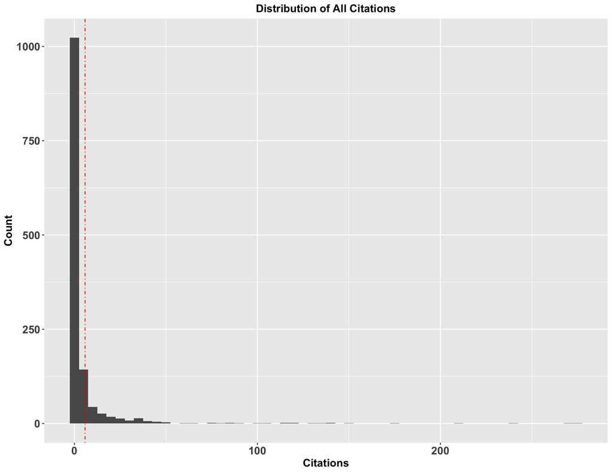

```r
#Plot by frequency, All
ggplot(ids_and_freqs_by_col, aes(x=Frequency)) +
  geom_histogram(binwidth=5) +
  ggtitle("Distribution of All Citations") +
  xlab("Citations") + ylab("Count") +
  geom_vline(xintercept = mean(ids_and_freqs_by_col$Frequency),
             linetype=4, colour="red") +
  theme(
    plot.title = element_text(size=14, face="bold",hjust = 0.5),
    axis.title.x = element_text(size=14, face="bold"),
    axis.title.y = element_text(size=14, face="bold"),
    strip.text.x = element_text(size=10, face="bold"),
    axis.text = element_text(size=14, face="bold"),
    legend.position = "none"
  )
```

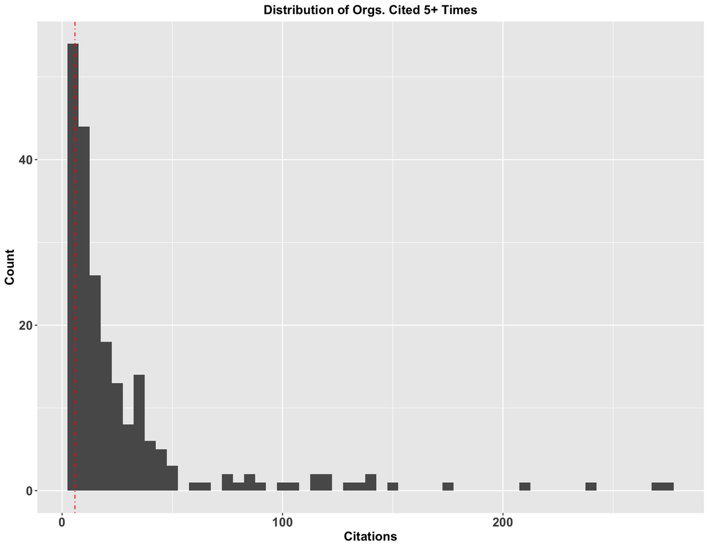

```r
#Plot by frequency, More than 5 appearences
ggplot(ids_and_freqs_by_col %>% filter(Frequency > 4), aes(x=Frequency)) +
  geom_histogram(binwidth=5) +
  ggtitle("Distribution of Orgs. Cited 5+ Times") +
  xlab("Citations") + ylab("Count") +
  geom_vline(xintercept = mean(ids_and_freqs_by_col$Frequency),
             linetype=4, colour="red") +
  theme(
    plot.title = element_text(size=14, face="bold",hjust = 0.5),
    axis.title.x = element_text(size=14, face="bold"),
    axis.title.y = element_text(size=14, face="bold"),
    strip.text.x = element_text(size=10, face="bold"),
    axis.text = element_text(size=14, face="bold"),
    legend.position = "none"
  )
```

## Limits of this Approach

This basic approach to extracting commenters is not without drawbacks. Briefly scrolling through the comments that were only cited once will show the various ways this approach fails for some comments. The primary driver of the errors is inconsistent formatting (e.g., omitting the semicolon between commenters or omitting the parenthesis showing where a commenter name ends).[^4]

```r
# Show limits
knitr::kable(ids_and_freqs_by_col %>%
               dplyr::select(Org, Detailed_Mentions) %>%
               arrange(Detailed_Mentions) %>%
               top_n(100),
             col.names = c("Organization","Detailed Cites")) %>%
  kable_styling(bootstrap_options = c("striped", "hover")) %>%
  scroll_box(width = "100%", height = "400px")
```

| Organization | Detailed Cites |
| --- | --- |
| 12 CFR 24015c3-1 | 1 |
| 12 USC 164 | 1 |
| 12 USC 1828a | 1 |
| 12 USC 1844 | 1 |
| 12 USC Part 362 | 1 |
| 17 CFR 230405 | 1 |
| 18 USC 1005 | 1 |
| A number of comments received regarding the definition of sponsor relate to securitization structures and are addressed below There also were a few comments urging that insurance companies not be cons… | 1 |
| A primary dealer is a firm that trades a sovereign government’s obligations directly with the sovereign | 1 |
| ABA | 1 |
| ACLI | 1 |
| AFR et al | 1 |
| Alfred Brock | 1 |
| Alfred Brock But Occupy | 1 |
| AllianceBernstein | 1 |
| Am Express | 1 |
| Appendix A of the final rule | 1 |
| Arnold & Porter | 1 |
| As discussed abovethe proposed rule generally included in the covered fund definition a foreign fund thatwere it organized or offered under the laws of the United States or offered to US residentswoul… | 1 |
| As noted abovesome commenters quantified the importance of banking entities to the provision of venture capital by providing information indicating that approximately 7 percent of all venture capital … | 1 |
| BEC | 1 |
| BlackRock | 1 |
| BOK | 1 |
| CalPERS | 1 |
| CFTC Proposal77 FR 8344 n107Furthera few commenters suggested that the exemption should only be available for trading on an organized trading facility This type of limitation would require significant… | 1 |
| CFTC Proposal77 FR 8440 RBC | 1 |
| CME Group | 1 |
| Comm on Capital Markets Regulation | 1 |
| Comm on Capital Markets Regulation Morgan Stanley | 1 |
| Commenters noted that the Board’s Regulation K contains a number of limitations that may not be appropriate to include as part of the requirements of the foreign trading exemption Allen & Overy | 1 |

[output cut: 115 more lines]